# Homework #5: Density Estimation

Your Name Here

Due: Wed Mar 24 | 10:55am

**SYS 4582/6018 | Spring 2021 | University of Virginia**

# Required R packages and Directories

```r
data.dir = 'https://mdporter.github.io/SYS6018/data/' # data directory
library(R6018)     # functions for SYS-6018
library(tidyverse) # functions for data manipulation
library(ks)        # functions for KDE
```

# Problem 1 Geographic Profiling

Geographic profiling, a method developed in criminology, can be used to estimate the [home location (roost) of animals](https://www.sciencedirect.com/science/article/pii/S0022519305004157) based on a collection of sightings. The approach requires an estimate of the distribution the animal will travel from their roost to forage for food.

A sample of 283 distances that pipistrelle bats traveled (in meters) from their roost can be found at: https://mdporter.github.io/SYS6018/data/geo_profile.csv

One probability model for the distance these bats will travel is:
$$\begin{align*}
f(x; \theta) = \frac{x}{\theta} \exp \left( - \frac{x^2}{2 \theta} \right)
\end{align*}$$
where the parameter $\theta > 0$ controls how far they are willing to travel.

## a. Derive the MLE for $\theta$ (i.e., show the math).

$$L(\theta)=\prod_{i=1}^nf(x_i,\theta)$$
$$log(L(\theta)) = \sum_i^n(\log{x_i} - \log{\theta} - \frac{x_i^2}{2\theta})$$
$$\frac{\partial{\log{L(\theta)}}}{\partial\theta} = \frac{n}{\theta} - \sum_i^n{\frac{x_i^2}{2*\theta^2}}=0$$
$$\frac{\sum_i^n{x_i^2}}{2*\theta^2} = \frac{n}{\theta}$$
$$\theta = \frac{\sum_i^nx_i^2}{2n}$$

## b. What is the MLE of $\theta$ for the bat data? (Use results from a, or use computational methods.)

```r
dataReader = read.csv("https://mdporter.github.io/SYS6018/data/geo_profile.csv",header = FALSE)

res.1b.sumvsq = sum(dataReader$V1*dataReader$V1)

res.1b = res.1b.sumvsq / (2*nrow(dataReader))
res.1b
```

```
#> [1] 4.524
```

## c. Using the MLE value of $\theta$ from part b, compute the estimated density at a set of evaluation points between 0 and 8 meters. Plot the estimated density.

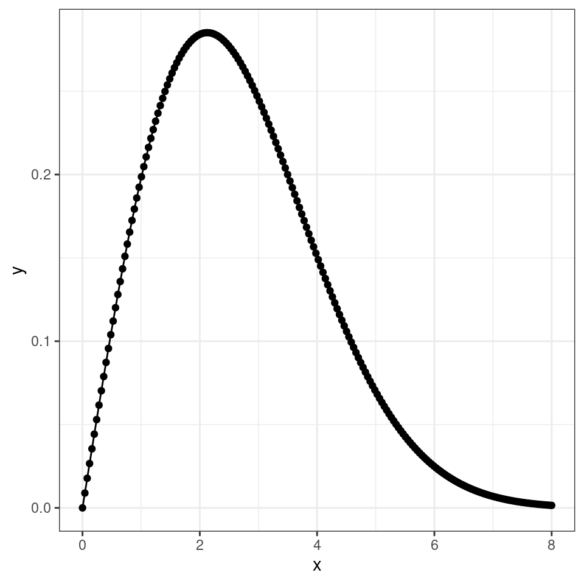

```r
func.1c <- function(x , theta){(x/theta)*exp(-x*x/(2*theta))}
x.seq = seq(0,8,length = 200)

dataplot.1c = tibble(x = x.seq,y=func.1c(x.seq,res.1b))

plot.1c.para = dataplot.1c %>%
  ggplot(aes(x,y)) + geom_point() + geom_line()

plot.1c.para
```

## d. Estimate the density using KDE. Report the bandwidth you chose and produce a plot of the estimated density.

```r
res.kde.1d = kde(dataReader$V1)
res.kde.1d$h
```

```
#> [1] 0.391
```

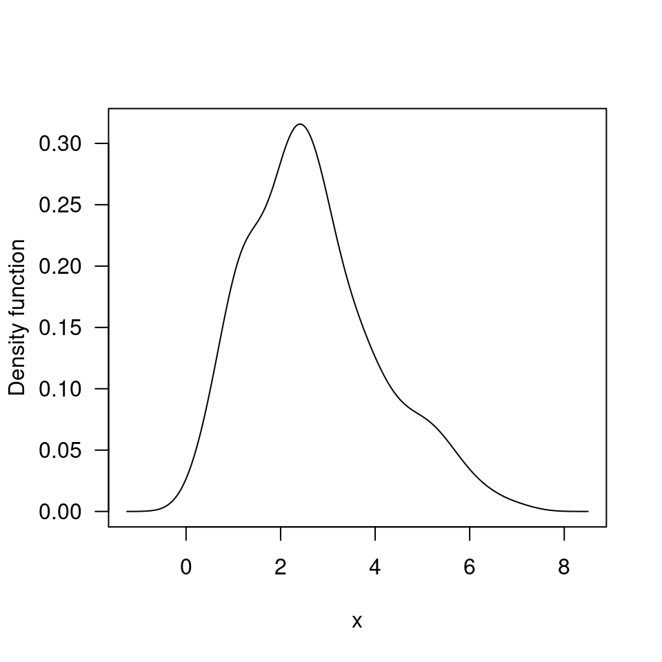

```r
plot(res.kde.1d,las = 1)
```

## e. Which model do you prefer, the parametric or KDE?

I prefer the KDE model, from the plot we can see, the parametric tend to have too large binary which tend to hide the detail features of the distribution.

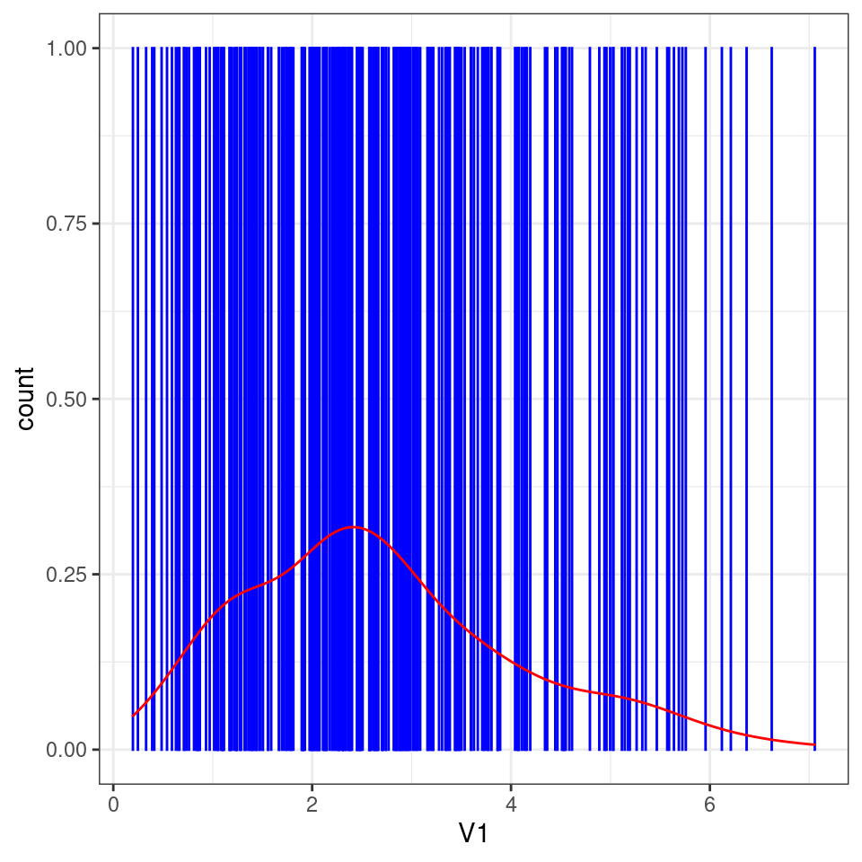

```r
ggplot(dataReader,aes(x=V1)) + geom_bar(color="Blue", fill="skyblue") + geom_density(color = "red")
```

# Problem 2: Interstate Crash Density

Interstate 64 (I-64) is a major east-west road that passes just south of Charlottesville. Where and when are the most dangerous places/times to be on I-64? The crash data (link below) gives the mile marker and fractional time-of-week for crashes that occurred on I-64 between mile marker 87 and 136 in 2016. The time-of-week data takes a numeric value of *<dow>.<hour/24>*, where the dow starts at 0 for Sunday (6 for Sat) and the decimal gives the time of day information. Thus `time=0.0417` corresponds to Sun at 1am and `time=6.5` corresponds to Sat at noon).

- **Crash Data**: https://mdporter.github.io/SYS6018/data//crashes16.csv

## a. Extract the crashes and make a scatter plot with mile marker on x-axis and time on y-axis.

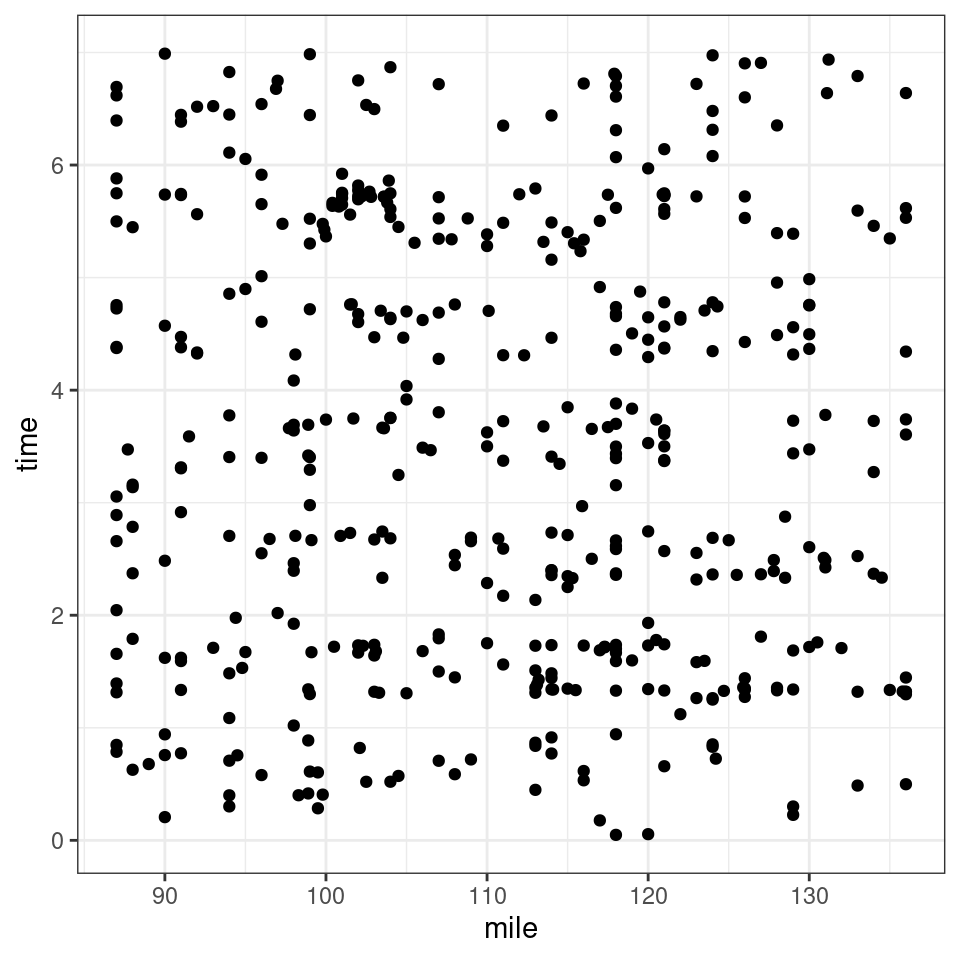

```r
dataReader2a = readr::read_csv("https://mdporter.github.io/SYS6018/data//crashes16.csv")

dataReader2a %>% ggplot(aes(mile,time)) + geom_point()
```

## b. Use KDE to estimate the *mile marker* density.

- Report the bandwidth.
- Plot the density estimate.

```r
res.kde.2b = kde(dataReader2a$mile)
res.kde.2b$h
```

```
#> [1] 2.894
```

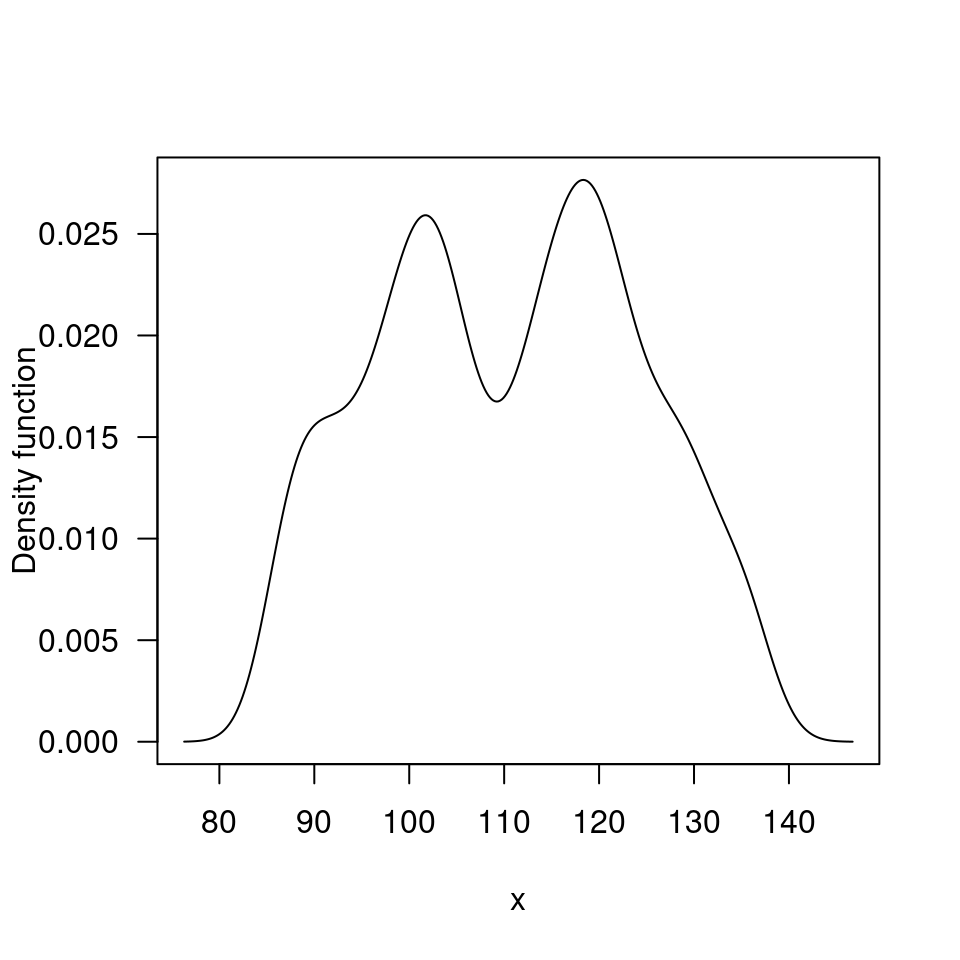

```r
plot(res.kde.2b,las = 1)
```

## c. Use KDE to estimate the temporal *time-of-week* density.

- Report the bandwidth.
- Plot the density estimate.

```r
res.kde.2c = kde(dataReader2a$time)
res.kde.2c$h
```

```
#> [1] 0.4141
```

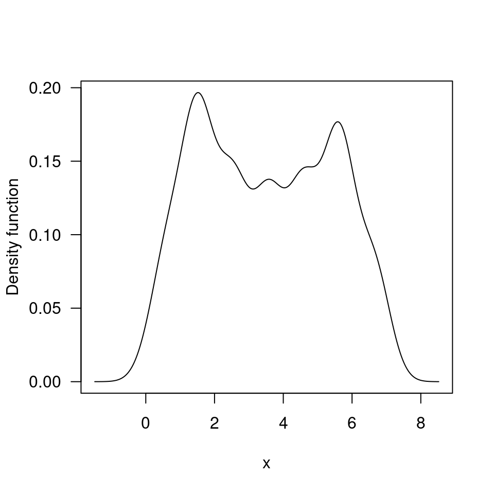

```r
plot(res.kde.2c,las =1 )
```

## d. Use KDE to estimate the bivariate mile-time density.

- Report the bandwidth parameters.
- Plot the bivariate density estimate.

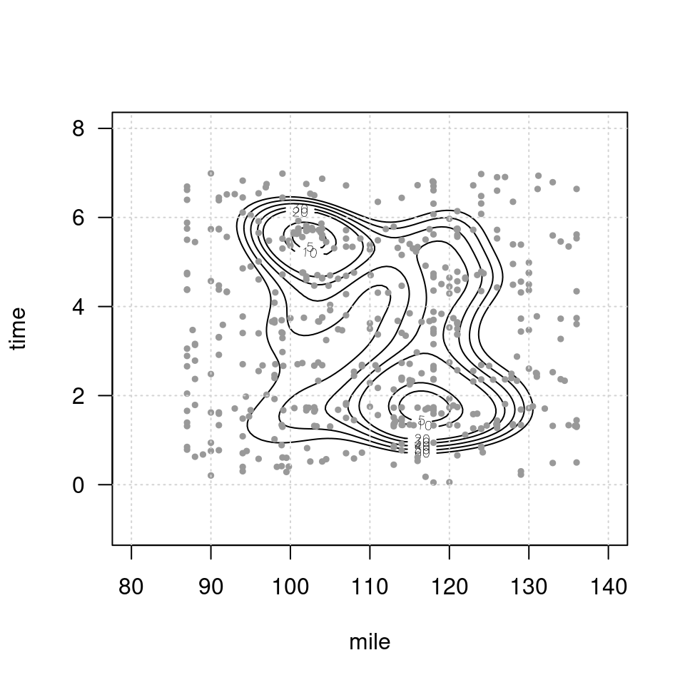

```r
H1 = Hscv(dataReader2a)
res.2d.kde = kde(dataReader2a,H = H1)


plot(res.2d.kde,
          cont = c(5,10,20,30,40,50,60),                        # set contour levels
     # display = "filled.contour",                # use filled contour
     las=1, xlim = c(80, 140), ylim=c(-1, 8)
     )
points(dataReader2a, pch = 19,cex = 0.5, col='grey60')
grid()
```

## e. Based on the estimated density, approximate the most dangerous mile marker and time-of-week.

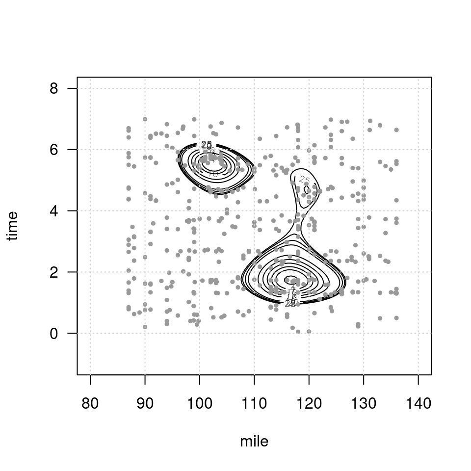

```r
plot(res.2d.kde,
          cont = seq(1,30,by=3),                        # set contour levels
     # display = "filled.contour",                # use filled contour
     las=1, xlim = c(80, 140), ylim=c(-1, 8)
     )
points(dataReader2a, pch = 19,cex = 0.5, col='grey60')
grid()
```

From the above plot we can see:

- The most dangerous miles marker and time-of-week is around $~(117,1.7)$. Mile marker : 117, on Monday 4.50pm
- second most dangerous miles marker and time-of week is around $~(103,5.5)$. Mile marker 103, on Friday Noon